# Laiko eilutės: praktinis atsiskaitymas

Evelina Vaitkevičiūtė

```r
rm(list = ls())
```

## Programinė įranga ir bibliotekos

```r
suppressPackageStartupMessages({
    suppressWarnings({
        library(tidyverse)
        library(forecast)
        library(ggplot2)
        library(data.table)
        library(moments)
        library(quantmod)
        library(rugarch)
        library(nortsTest)
        library(FinTS)
        })
    })
```

## Duomenų parsiuntimas

Žemiau pateikiamas kodas, nurodant studento kodą `STUDENT_CODE = X`:

```r
getData <- function(s_code){
  set.seed(s_code)
  symbols_stocks <- c("NVDA", "INTC", "AMD", "META", "AAPL", "MSFT",
                   "IBM", "NFLX", "GOOGL", "AMZN", "EBAY", "BABA",
                   "DIS", "TSLA", "KO", "PEP", "ADBE",
                   "AAL", "HPQ", "MCD", "NDAQ")
  my_symbols <- c(sample(symbols_stocks, 1))
  print(paste0("Simboliai: ", sub("\\^", "", my_symbols)))
  #
  library(quantmod)
  for(var_names in my_symbols){
    # Get the symbol:
    getSymbols(var_names,  auto.assign = TRUE,
               src  = "yahoo",
               from = "2015-01-01",
               to   = "2023-06-25")
    # Automatically remove missing data from the variable:
    assign(gsub("\\^", "", var_names), na.omit(get(gsub("\\^", "", var_names))))
  }
  return(get(var_names))
}
DT <- getData(X)
```

```
## [1] "Simboliai: MCD"
```

```r
saveRDS(DT, "./laiko_eiluciu_duom.RDS")
```

**SIMBOLIS** MCD - **ĮMONĖ** Mcdonald’s Corp.

## Pradinė analizė

Laikykime, kad:  
laikas yra nuoseklus (t.y. ignoruokime nedarbo dienas ir laikotarpius su tuščiomis (`NA`) reikšmėmis),  
ignoruokime valiutų kurso efektus,  
$P^{(F)}_{t}$ - nagrinėjamos įmonės akcijų **uždarymo** kaina (angl. *closing price*) laiko momentu $t$.

##### Pasirenkamos tik tos DT eilutės, kurios neturi `NA` reikšmių.

```r
DT <- DT[rowSums(is.na(DT)) == 0]
```

##### DT rinkinys:

```r
head(DT)
```

```
##            MCD.Open MCD.High MCD.Low MCD.Close MCD.Volume MCD.Adjusted
## 2015-01-02    94.13    95.00   93.05     93.26    6019700     73.65234
## 2015-01-05    93.30    93.68   92.22     92.23    6211900     72.83888
## 2015-01-06    92.67    93.81   91.88     92.40    6484100     72.97313
## 2015-01-07    93.26    94.05   92.86     94.01    6400300     74.24463
## 2015-01-08    94.23    94.98   94.05     94.36    5476700     74.52105
## 2015-01-09    93.97    93.97   92.78     93.21    4283300     73.61285
```

##### Duomenų rinkinio stulpelių pavadinimai:

```r
ls(DT)
```

```
## [1] "MCD.Adjusted" "MCD.Close"    "MCD.High"     "MCD.Low"      "MCD.Open"
## [6] "MCD.Volume"
```

##### Aprašomoji statistika

```r
summary(DT)
```

```
##      Index               MCD.Open         MCD.High         MCD.Low
##  Min.   :2015-01-02   Min.   : 89.39   Min.   : 89.82   Min.   : 87.5
##  1st Qu.:2017-02-14   1st Qu.:128.08   1st Qu.:128.74   1st Qu.:127.5
##  Median :2019-03-29   Median :183.04   Median :184.49   Median :181.5
##  Mean   :2019-03-28   Mean   :183.44   Mean   :184.82   Mean   :182.1
##  3rd Qu.:2021-05-11   3rd Qu.:231.50   3rd Qu.:232.89   3rd Qu.:230.2
##  Max.   :2023-06-23   Max.   :298.63   Max.   :298.86   Max.   :296.3
##    MCD.Close        MCD.Volume        MCD.Adjusted
##  Min.   : 88.78   Min.   :  963200   Min.   : 70.11
##  1st Qu.:128.14   1st Qu.: 2571500   1st Qu.:107.49
##  Median :183.17   Median : 3300200   Median :163.22
##  Mean   :183.47   Mean   : 3967160   Mean   :166.11
##  3rd Qu.:231.68   3rd Qu.: 4647500   3rd Qu.:217.16
##  Max.   :298.07   Max.   :25286600   Max.   :291.50
```

## Duomenų filtravimas ir paruošimas analizei

```r
DT_old <- copy(DT)

cols <- grep(".Close", colnames(DT), value = TRUE)
cols
```

```
## [1] "MCD.Close"
```

```r
DT <- data.frame(time = index(DT), value = DT[, cols])
DT <- as.data.table(DT)

DT <- DT[rowSums(is.na(DT)) == 0]
```

## Duomenų transformacija iš akcijų kainos į akcijų grąžą

Pasinaudojus įmonės akcijų ir akcijų indekso simbolių uždarymo kainomis apskaičiuojamos paprastosios grąžos (angl. *simple returns*). Paprastosios grąžos išreiškiamos logaritmuota išraiška ir toliau analizuojamos logaritmuotos grąžos (angl. *log-returns*).

Apibendrinant - paprastoji grąža rodo kainos pokytį, lyginant su praeitu laiko momentu; kainų pokytis per periodą (per dieną, dienos eina nuosekliai. Formulė:

$L_{t}\equiv \frac{V_{t+1}}{V_{t}} - 1$

Logaritminė grąža (jei pokyčiai būna nedideli) dažnai rodo panašaus dydžio reikšmes ir dėl to dažnai interpretuojama kaip kainos pokytis. Formulė:

$C_{t}\equiv \ln\left( \frac{V_{t+1}}{V_{t}} \right)$

```r
DT[, c(gsub("Close", "r.simple", cols)) := lapply(.SD, function(x){x / shift(x, n = 1, type = "lag") - 1}), .SDcols = cols]

DT[, c(gsub("Close", "r.log", cols)) := lapply(.SD, function(x){log(x) - shift(log(x), n = 1, type = "lag")}), .SDcols = cols]
```

```r
DT[, c("time", grep("simple|log", colnames(DT), value = TRUE)), with = FALSE] %>% head(5)
```

```
##          time MCD.r.simple    MCD.r.log
## 1: 2015-01-02           NA           NA
## 2: 2015-01-05 -0.011044381 -0.011105823
## 3: 2015-01-06  0.001843207  0.001841511
## 4: 2015-01-07  0.017424242  0.017274181
## 5: 2015-01-08  0.003722997  0.003716084
```

Alternatyvus sprendimas, naudojant `quantmod` biblioteką:

```r
DT$Simple_return <- Delt(DT$MCD.Close, type = "arithmetic")
DT$Log_return <- Delt(DT$MCD.Close, type = "log")
```

Panaikinama pirmosios reikšmės (eilutė), kadangi skaičiuojant grąžas pačią pirmą dieną neturime prieš tai buvusios vertės.

```r
DT <- DT[-1, ]
```

```r
DT[, c("time", grep("simple|log", colnames(DT), value = TRUE)), with = FALSE] %>% head(5)
```

```
##          time MCD.r.simple    MCD.r.log
## 1: 2015-01-05 -0.011044381 -0.011105823
## 2: 2015-01-06  0.001843207  0.001841511
## 3: 2015-01-07  0.017424242  0.017274181
## 4: 2015-01-08  0.003722997  0.003716084
## 5: 2015-01-09 -0.012187389 -0.012262264
```

##### Paprastųjų ir logaritminių grąžų vizualizavimas

Iš grafiko matome, kad ten, kur yra didesni skirtumai, ten labiau išsiskiria paprastųjų ir logaritminių grąžos. Logaritmuodami bandome užtikrinti, kad grąžos būtų arčiau normaliojo skirstinio ir būtų mažiau ekstremalių reikšmių, tai palengvina darbą, darant prielaidas: Inovacijos turi normalųjį skirstinį su 0 vidurkiu ir 1 dispersija.

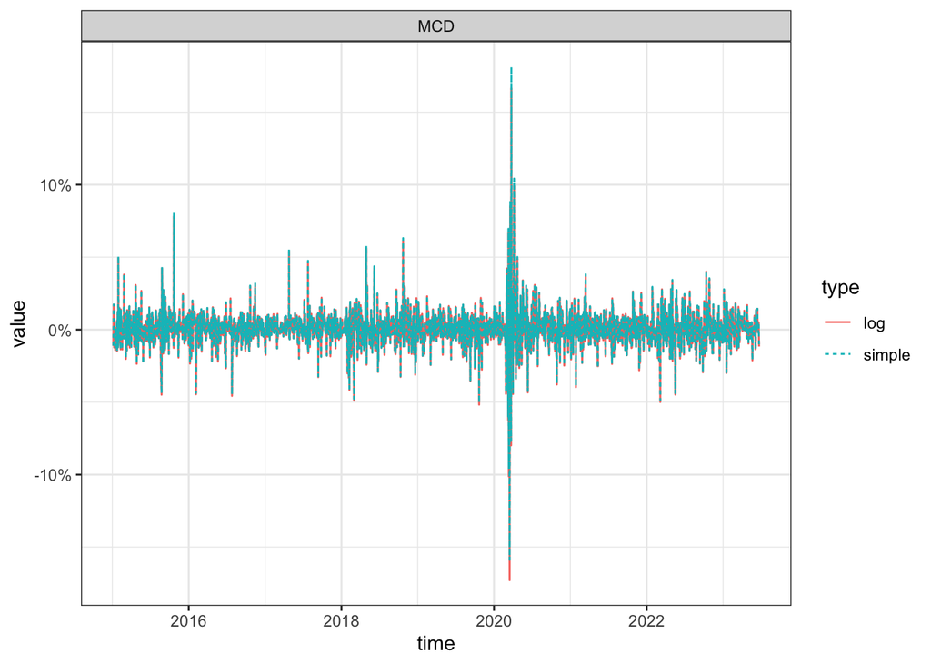

```r
options(repr.plot.width = 15, repr.plot.height = 15, repr.plot.res = 200)

DT[, c("time", grep("simple|log", colnames(DT), value = TRUE)), with = FALSE] %>%
  melt.data.table(id.vars = "time") %>%
  .[, .(time, type = gsub("^.*\\.", "", variable), variable = gsub("\\..*", "", variable), value)] %>%
  ggplot(aes(x=time, y = value, color=type, linetype=type)) +
  geom_line() +
  scale_y_continuous(labels = scales::percent) +
  facet_wrap(~variable, scales = "free_y", ncol = 1) + theme_bw()
```

Toliau analizuojamos logaritmuotos grąžos.

```r
log_returns <- DT$MCD.r.log
```

## Logaritmuotų grąžų vidurkio, standartinio nuokrypio, asimetrijos ir eksceso koeficientų apskaičiavimas

Vidurkis

```r
mean_log_returns <- mean(log_returns)
cat("Vidurkis:", mean_log_returns)
```

```
## Vidurkis: 0.000531979
```

Standartinis nuokrypis

```r
sd_log_returns <- sd(log_returns)
cat("Standartinis nuokrypis:", sd_log_returns)
```

```
## Standartinis nuokrypis: 0.01326627
```

[Asimetrijos (angl. *skewness*) koeficientas](https://www.statology.org/skewness-kurtosis-in-r/)

```r
skewness_log_returns <- skewness(log_returns)
cat("Asimetrijos koeficientas:", skewness_log_returns)
```

```
## Asimetrijos koeficientas: -0.1411418
```

Kadangi asimetrijos koeficientas yra neigiamas, tai rodo, kad pasiskirstymas yra asimetriškas (left-skewed).

[Eksceso (angl. *excess kurtosis*) koeficientas](https://www.statology.org/skewness-kurtosis-in-r/)

```r
kurtosis_log_returns <- kurtosis(log_returns)
cat("Eksceso koeficientas:", kurtosis_log_returns)
```

```
## Eksceso koeficientas: 34.51293
```

Pavaizduojama logaritminių grąžų histograma:

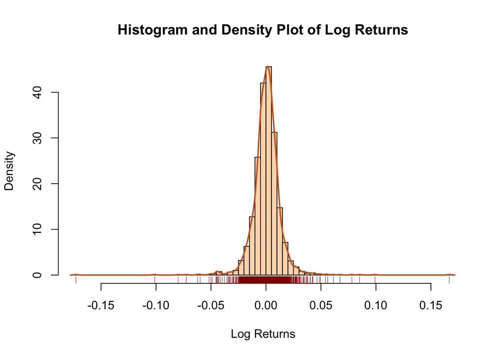

```r
hist(log_returns,
     col = "peachpuff",
     border = "black",
     prob = TRUE,
     breaks = 50,
     main = "Histogram and Density Plot of Log Returns",
     xlab = "Log Returns")
density_log_returns <- density(log_returns)
lines(density_log_returns,
      lwd = 2,
      col = "chocolate3")
rug(log_returns, col = "darkred")
```

## Statistinių testų atlikimas

- Patikrinti ar vidurkis statistiškai reikšmingai nesiskiria nuo nulio:  
  $H_{0}:$ vidurkis nesiskiria nuo 0  
  $H_{A}:$ vidurkis skiriasi nuo 0

```r
t.test(log_returns)
```

```
##
##  One Sample t-test
##
## data:  log_returns
## t = 1.8516, df = 2131, p-value = 0.06423
## alternative hypothesis: true mean is not equal to 0
## 95 percent confidence interval:
##  -3.146397e-05  1.095422e-03
## sample estimates:
##   mean of x
## 0.000531979
```

Kadangi p-value = 0.06423 > 0.05, negalime atmesti $H_{0}$ hipotezės. Vadinasi, vidurkis statistiškai reikšmingai nesiskiria nuo 0.

- Patikrinti ar asimetrijos koeficientas statistiškai reikšmingai nesiskiria nuo nulio:  
  $H_{0}: S(r)=0$ (nėra asimetrijos) asimetrijos koeficientas nesiskiria nuo 0  
  $H_{A}:$ asimetrijos koeficientas skiriasi nuo 0

```r
n <- length(log_returns[!is.na(log_returns)])
skewness_test_statistic <- skewness_log_returns / (sqrt(6 / n))
skewness_p_value <- 2 * (1 - pnorm(abs(skewness_test_statistic)))
skewness_p_value
```

```
## [1] 0.007801004
```

```r
moments::agostino.test(log_returns) # H_0: S(r) = 0
```

```
##
##  D'Agostino skewness test
##
## data:  log_returns
## skew = -0.14114, z = -2.65686, p-value = 0.007887
## alternative hypothesis: data have a skewness
```

- Patikrinti ar eksceso koeficientas statistiškai reikšmingai nesiskiria nuo nulio:  
  $H_{0}: K(r)-3=0$ (nėra asimetrijos) eksceso koeficientas nesiskiria nuo 0  
  $H_{A}:$ eksceso koeficientas skiriasi nuo 0

```r
n <- length(log_returns[!is.na(log_returns)])
excess_kurtosis <- kurtosis_log_returns  - 3
kurtosis_test_statistic <- excess_kurtosis / (sqrt(24 / n))
kurtosis_p_value <- 2 * (1 - pnorm(abs(kurtosis_test_statistic)))
kurtosis_p_value
```

```
## [1] 0
```

```r
moments::anscombe.test(log_returns) # H_0: K(r) = 3
```

```
##
##  Anscombe-Glynn kurtosis test
##
## data:  log_returns
## kurt = 34.513, z = 25.182, p-value < 2.2e-16
## alternative hypothesis: kurtosis is not equal to 3
```

Kadangi p-value = 0 < 0.05, $H_{0}$ hipotezę atmetame. Vadinasi, eksceso koeficientas skiriasi nuo 0.

$H_{0}:$ duomenys atitinka normalųjį pasiskirstymą  
$H_{A}:$ duomenys neatitinka normaliojo pasiskirstymo

```r
jarque.test(log_returns)
```

```
##
##  Jarque-Bera Normality Test
##
## data:  log_returns
## JB = 88224, p-value < 2.2e-16
## alternative hypothesis: greater
```

Kadangi p-value = 2.2e-16 < 0.05, $H_{0}$ hipotezę atmetame. Vadinasi, duomenys neturi normaliojo pasiskirstymo.

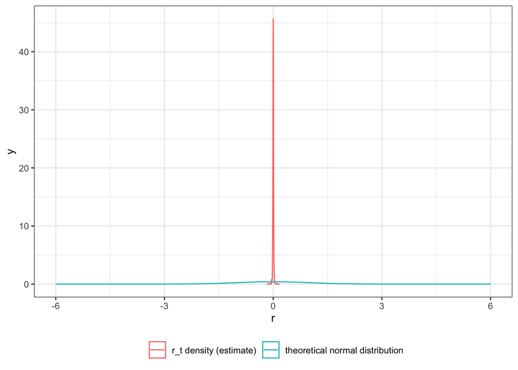

```r
data.frame(time = 1:nrow(DT), r = log_returns) %>%
  ggplot(aes(x = r)) + geom_density(aes(color = "r_t density (estimate)")) +
  stat_function(aes(color = "theoretical normal distribution"),
                fun = dnorm, args = c(0, 1), n = 1000, xlim = c(-6, 6), show.legend = TRUE) +
  theme_bw() + theme(legend.position = "bottom", legend.title = element_blank())
```

Matome, kad $r_{t}$ skirstinys nėra simetrinis.

Bandant sudaryti modelį koeficientai nėra statistiškai reikšmingi, todėl sumažiname analizuojamų duomenų laikotarpį, pvz. pradžia nuo 2020 sausio mėn.

```r
DT[, time := as.Date(time)]
DT_filtered <- DT[time >= as.Date("2020-01-01")]
```

Logaritminės grąžos, sumažinus analizuojamų duomenų laikotarpį:

```r
log_returns <- DT_filtered$MCD.r.log
```

## Laiko eilutės grafikas ir jos tyrimas

Issibrėžiamas laiko eilutės grafikas ir ištiriama laiko eilutė (pačios laiko eilutės grafikas, ACF, PACF ir kiti grafikai, Ljung-box testas).

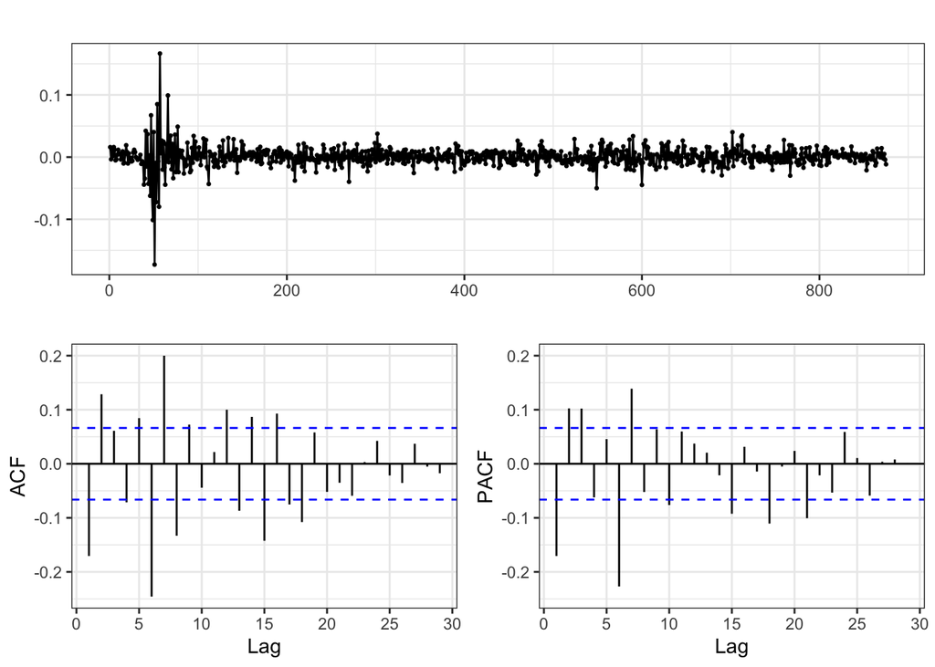

```r
forecast::ggtsdisplay(DT_filtered$MCD.r.log, theme = theme_bw())
```

Vidurkis 0, dispersija - yra tam tikrų periodų, kur yra šuolių. Autokoreliacija / dalinė autokoreliacija - yra reikšmingų lag’ų.

Jei generuosime `ARCH(2)` daugiau lag’ų bus reikšmingų.

Patikrinsime logaritminės grąžos kvadratų ACF ir PACF $R^{2}_{t}$:

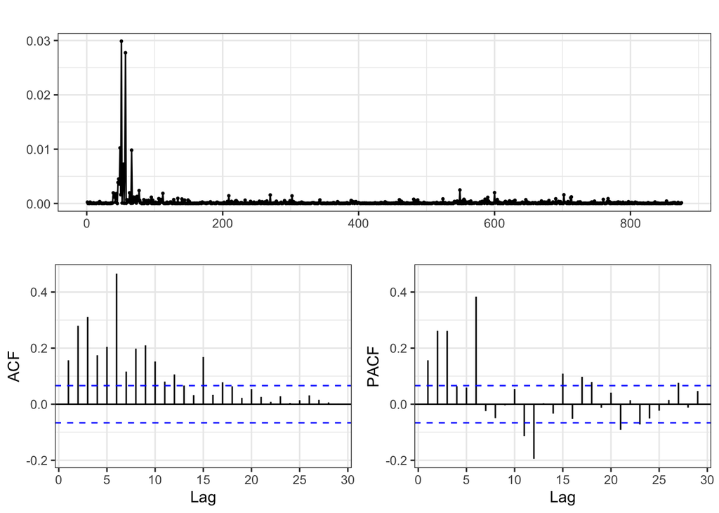

```r
forecast::ggtsdisplay(DT_filtered$MCD.r.log^2, theme = theme_bw())
```

```r
Box.test(DT_filtered$MCD.r.log, lag = 10)
```

```
##
##  Box-Pierce test
##
## data:  DT_filtered$MCD.r.log
## X-squared = 163.49, df = 10, p-value < 2.2e-16
```

```r
nortsTest::arch.test(DT_filtered$MCD.r.log^2, lag.max = 10)
```

```
##
##  Box-Ljung test
##
## data:  y^2
## X-squared = 227.71, df = 10, p-value < 2.2e-16
## alternative hypothesis: y is heteroscedastic
```

Matome, kad visais atvejais p reikšmė < 0,05, todėl atmetame $H_{0}$ hipotezę, kad autokoreliacijos lygios nuliui. Neatmetame hipotezės, kad log grąžos ($r^{2}$) yra autokoreliuotos. ARCH effektai - vidurkio liekanos autokoreliuotos, ir jų kvadratai - autokoreliuoti.

Apskaičiuokime volatilumą $\hat{u_{t}^{2}}$ $\Delta\log(Y_{t}) = \alpha + u_{t}$

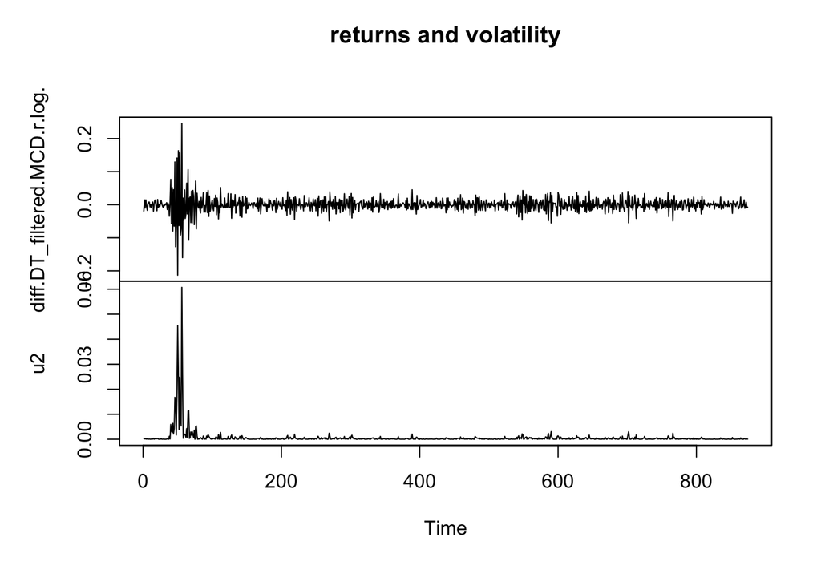

```r
mdl <- lm(diff(DT_filtered$MCD.r.log) ~ 1)
u <- residuals(mdl)
u2<- u^2
plot.ts(data.frame(diff(DT_filtered$MCD.r.log), u2),
main = "returns and volatility")
```

Mažas kintamumas stabiliais laikotarpiais.

## Treniravimo ir testavimo aibės

Laiko eilutė padalinama į treniravimo (80%) ir testavimo (likę 20%) imtis (originalūs duomenys - su trendu/sezoniškumu)

Toliau dirbama su treniravimo imtimi.

```r
train_size <- floor(0.8 * nrow(DT_filtered))
train_data <- DT_filtered[1:train_size, ]
test_data <- DT_filtered[(train_size+1):nrow(DT_filtered), ]
```

Sezoniškumas:

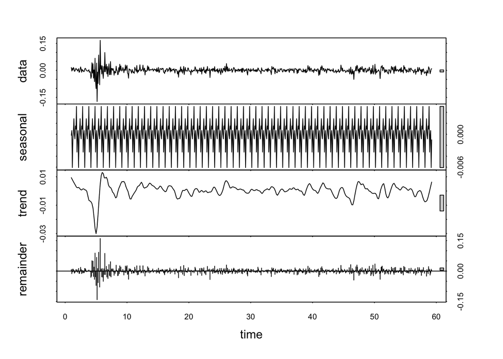

```r
ts_data <- ts(train_data$MCD.r.log, frequency = 12)
stl_data <- stl(ts_data, s.window = "periodic")

plot(stl_data)
```

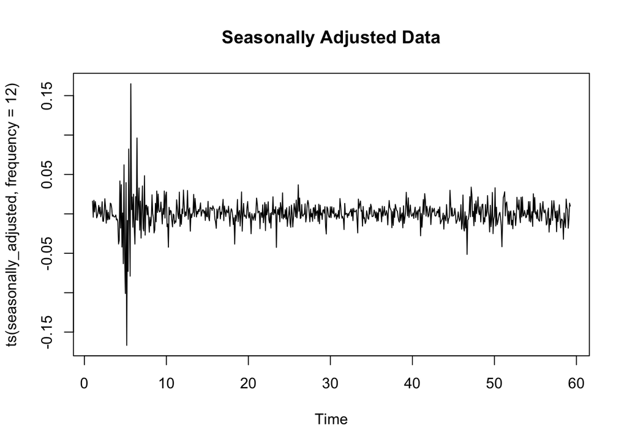

```r
seasonally_adjusted <- ts_data - stl_data$time.series[, "seasonal"]
plot(ts(seasonally_adjusted, frequency = 12), main = "Seasonally Adjusted Data")
```

## Modelio sudarymas (vidurkio lygtis) - ARMA modelis

Liekanos turėtų būti nekoreliuotos, turėti nulinį vidurkį ir pastovią dispersiją.

`auto.arima`grąžina geriausią ARIMA modelį pagal AIC, AICc arba BIC vertę.

```r
fit_arma <- auto.arima(train_data[, MCD.r.log])
summary(fit_arma)
```

```
## Series: train_data[, MCD.r.log]
## ARIMA(5,0,5) with zero mean
##
## Coefficients:
##           ar1     ar2     ar3     ar4     ar5     ma1      ma2     ma3      ma4
##       -0.3238  0.5744  0.0133  0.0884  0.5089  0.2041  -0.5415  0.2267  -0.2492
## s.e.   0.1904  0.2198  0.1444  0.2218  0.1180  0.1785   0.1820  0.1285   0.1805
##           ma5
##       -0.5784
## s.e.   0.0909
##
## sigma^2 = 0.0002648:  log likelihood = 1894.08
## AIC=-3766.17   AICc=-3765.79   BIC=-3716.11
##
## Training set error measures:
##                        ME       RMSE       MAE MPE MAPE     MASE       ACF1
## Training set 0.0006776807 0.01615531 0.0103974 Inf  Inf 0.652741 0.02164286
```

Geriausiam ARMA modeliui pasirinkti, galima sudaryti algoritmą:

```r
aic_table = function(train_data,P,Q){
  table = matrix(NA,(P+1),(Q+1))
  for (p in 0:P){
    for (q in 0:Q){
      table[p+1,q+1] = arima(train_data,order=c(p,0,q))$aic
    }
  }
  dimnames(table) = list(paste("<b> AR",0:P,"</b>",sep=""),paste("MA",0:Q,sep=""))
  table
}
ret_aic_table = aic_table(train_data$MCD.r.log,5,5)
require(knitr)
kable(ret_aic_table,digits=2)
```

|  | MA0 | MA1 | MA2 | MA3 | MA4 | MA5 |
| --- | --- | --- | --- | --- | --- | --- |
| **AR0** | -3667.63 | -3684.38 | -3702.74 | -3704.73 | -3705.25 | -3704.25 |
| **AR1** | -3689.50 | -3690.87 | -3703.17 | -3729.77 | -3727.82 | -3728.40 |
| **AR2** | -3695.88 | -3697.62 | -3707.01 | -3727.89 | -3735.31 | -3733.42 |
| **AR3** | -3703.03 | -3741.77 | -3754.60 | -3754.61 | -3733.52 | -3737.23 |
| **AR4** | -3703.91 | -3741.27 | -3747.30 | -3757.52 | -3758.92 | -3760.09 |
| **AR5** | -3703.60 | -3747.17 | -3745.88 | -3762.39 | -3759.65 | -3768.36 |

Iš lentelės matome, kad ARMA(5,0,5) turi mažiausią AIC. Taigi pasirinksime ARMA(5,0,5). Tačiau šis modelis yra sudėtingas, todėl gali kilti tokių problemų kaip overfitting, numerical stability ir kt.

Modelis: $r_{t} = \mu + \phi_{1}r_{t-1} + \ldots + \phi_{5}r_{t-5} + \epsilon_{t} + \theta_{1}r_{t-1} + \ldots + \theta_{5}r_{t-5}$

## Modelio liekanų analizė:

Tikrinama ar liekanos autokoreliuotos:

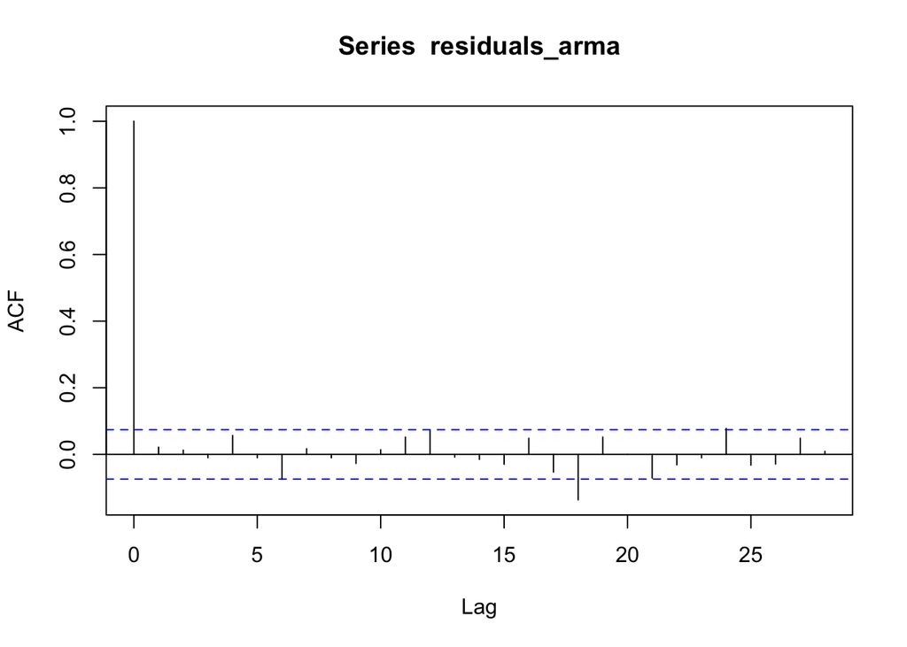

```r
residuals_arma <- residuals(fit_arma)
acf(residuals_arma)
```

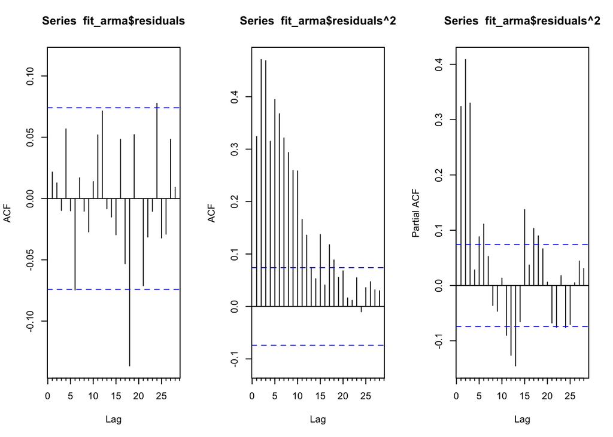

```r
par(mfrow = c(1,3))
forecast::Acf(fit_arma$residuals)
forecast::Acf(fit_arma$residuals^2)
forecast::Pacf(fit_arma$residuals^2)
```

Tikrinama ar liekanoms būdingi ARCH efektai:  
$H_{0}:$ liekanose nėra ARCH efektų  
$H_{A}:$ liekanoms būdingi ARCH efektai

```r
ArchTest(residuals_arma)
```

```
##
##  ARCH LM-test; Null hypothesis: no ARCH effects
##
## data:  residuals_arma
## Chi-squared = 254.05, df = 12, p-value < 2.2e-16
```

Kadangi p reikšmė < 0.05, atmetame $H_{0}$ hipotezę. Vadinasi, liekanoms būdingi ARCH efektai.

## Modelio sudarymas vidurkio modelio liekanoms(volatilumo/dispersijos lygtis)

```r
garch_spec <- ugarchspec(variance.model = list(model = "sGARCH", garchOrder = c(1, 1)),
                         mean.model = list(armaOrder = c(5, 5), include.mean = TRUE))

garch_fit <- ugarchfit(spec = garch_spec, data = fit_arma$residuals)
summary(garch_fit)
```

```
##    Length     Class      Mode
##         1 uGARCHfit        S4
```

```r
garch_fit
```

```
##
## *---------------------------------*
## *          GARCH Model Fit        *
## *---------------------------------*
##
## Conditional Variance Dynamics
## -----------------------------------
## GARCH Model  : sGARCH(1,1)
## Mean Model   : ARFIMA(5,0,5)
## Distribution : norm
##
## Optimal Parameters
## ------------------------------------
##         Estimate  Std. Error   t value Pr(>|t|)
## mu     -0.000488    0.000001  -341.577        0
## ar1     0.629262    0.000299  2105.279        0
## ar2    -0.400704    0.000247 -1625.170        0
## ar3     0.901423    0.000272  3308.435        0
## ar4    -0.603324    0.000237 -2543.979        0
## ar5     0.459785    0.000174  2641.340        0
## ma1    -0.539954    0.000123 -4381.868        0
## ma2     0.273082    0.000070  3921.102        0
## ma3    -0.927229    0.000195 -4758.642        0
## ma4     0.544314    0.000126  4309.545        0
## ma5    -0.373282    0.000094 -3972.476        0
## omega   0.000011    0.000001    10.987        0
## alpha1  0.142480    0.011982    11.891        0
## beta1   0.796692    0.021076    37.800        0
##
## Robust Standard Errors:
##         Estimate  Std. Error    t value Pr(>|t|)
## mu     -0.000488    0.000001  -527.5324        0
## ar1     0.629262    0.000702   896.5791        0
## ar2    -0.400704    0.000455  -880.1799        0
## ar3     0.901423    0.001008   894.3230        0
## ar4    -0.603324    0.000668  -903.0775        0
## ar5     0.459785    0.000507   906.3221        0
## ma1    -0.539954    0.000290 -1863.6647        0
## ma2     0.273082    0.000162  1686.1621        0
## ma3    -0.927229    0.000989  -937.6698        0
```

[output cut: 67 more lines]

```
## Negative Sign Bias 0.08708 0.9306
## Positive Sign Bias 0.01902 0.9848
## Joint Effect       1.83585 0.6072
##
##
## Adjusted Pearson Goodness-of-Fit Test:
## ------------------------------------
##   group statistic p-value(g-1)
## 1    20     27.14       0.1014
## 2    30     34.83       0.2102
## 3    40     44.11       0.2642
## 4    50     58.71       0.1612
##
##
## Elapsed time : 1.472055
```

## Volatilumo lygties standartizuotų liekanų analizė

Jei $u_{t}=\sigma_{t}\epsilon_{t} ∼ N(0,\sigma^{2}_{t})$, tai $u_{t}/\sigma_{t}∼N(0,1)$. Standartizuojame liekanas ir patikriname, ar joms būdingi ARCH efektai:

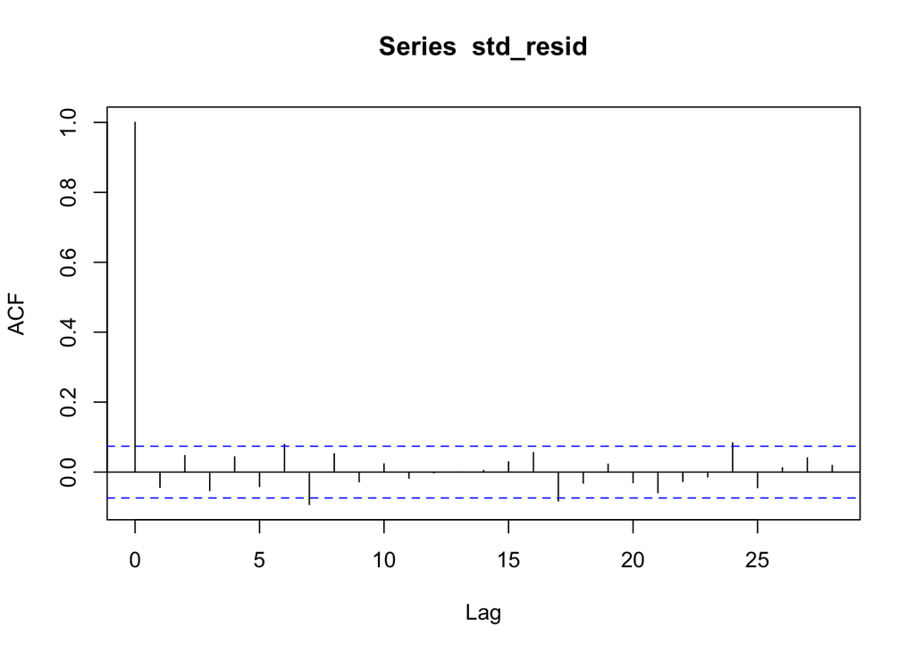

```r
std_resid <- residuals(garch_fit, standardize = TRUE)
acf(std_resid)
```

```r
ArchTest(std_resid)
```

```
##
##  ARCH LM-test; Null hypothesis: no ARCH effects
##
## data:  std_resid
## Chi-squared = 8.2571, df = 12, p-value = 0.7647
```

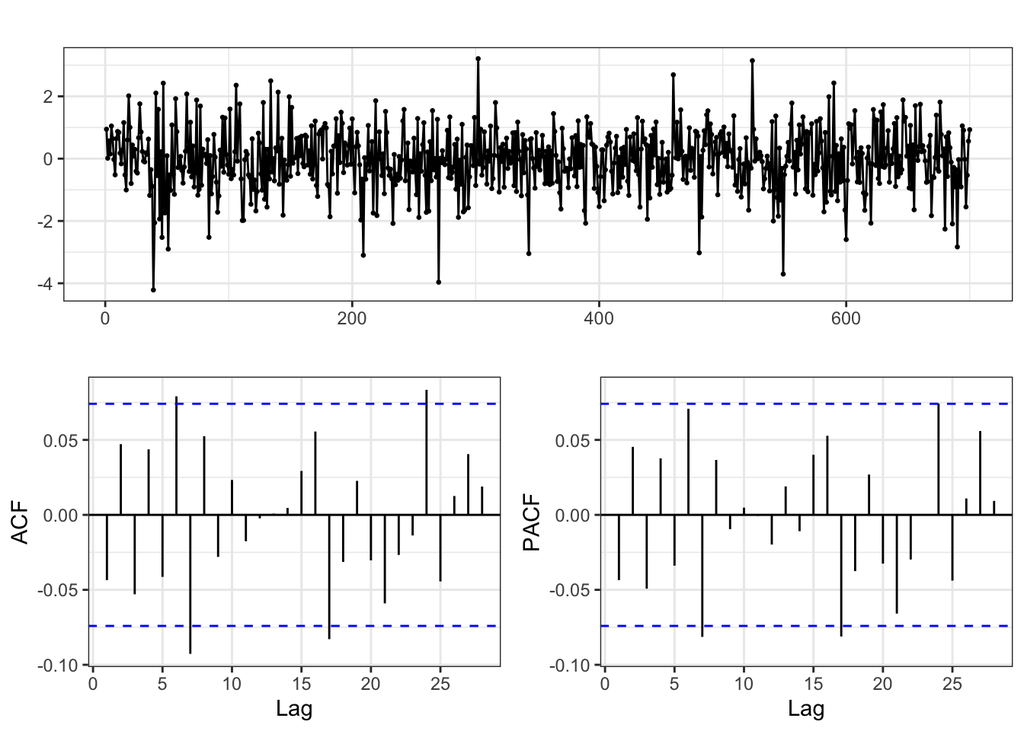

```r
ggtsdisplay(garch_fit@fit$residuals / garch_fit@fit$sigma, theme = theme_bw())
```

Kadangi p reikšmė > 0.05, nėra pagrindo atmesti $H_{0}$ hipotezę. Vadinasi, liekanoms nėra būdingi ARCH efektai.

## Jungtinio modelio sudarymas

```r
joint_spec <- ugarchspec(variance.model = list(model = "sGARCH", garchOrder = c(1, 1)),
                         mean.model = list(armaOrder = c(5, 5), include.mean = TRUE))

joint_fit <- ugarchfit(spec = joint_spec, data = train_data[, MCD.r.log])
summary(joint_fit)
```

```
##    Length     Class      Mode
##         1 uGARCHfit        S4
```

## Jungtinio modelio liekanų analizė

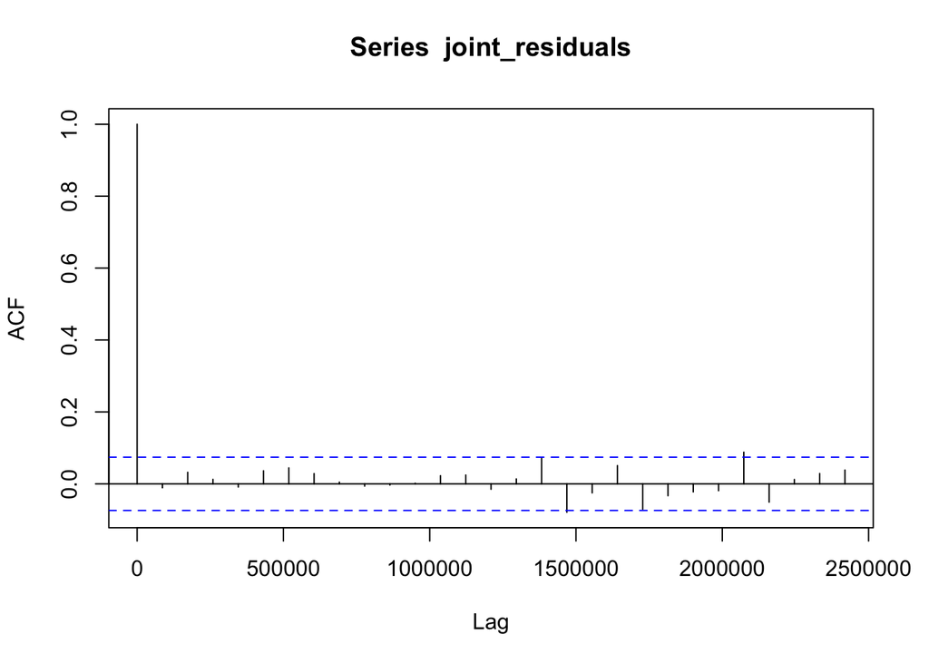

```r
joint_residuals <- residuals(joint_fit, standardize = TRUE)
acf(joint_residuals)
```

```r
ArchTest(joint_residuals)
```

```
##
##  ARCH LM-test; Null hypothesis: no ARCH effects
##
## data:  joint_residuals
## Chi-squared = 4.7475, df = 12, p-value = 0.9659
```

Kadangi ARCH LM-test p reikšmė = 0.9659 > 0.05, rodo kad ARCH efektų liekanose nebėra.

Taigi, mūsų įvertintas modelis yra teisingai apibrėžtas ta prasme, kad ACF/PACF autokoreliacija yra palyginti silpna.

## Volatilumo prognozės

```r
joint_forecast <- ugarchforecast(joint_fit, n.ahead = nrow(test_data))
predicted_volatility <- sigma(joint_forecast)

actual_returns <- test_data[, MCD.r.log]
```

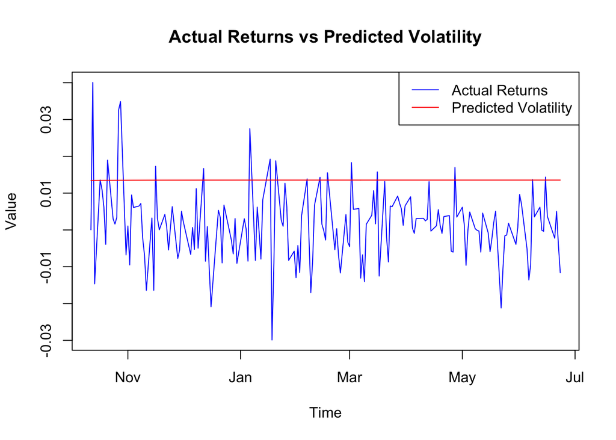

```r
plot(test_data$time, actual_returns, type = 'l', col = 'blue', main = "Actual Returns vs Predicted Volatility", xlab = "Time", ylab = "Value")
lines(test_data$time, predicted_volatility, col = 'red')
legend("topright", legend = c("Actual Returns", "Predicted Volatility"), col = c("blue", "red"), lty = 1)
```

Apskaičiuojama faktinės grąžos standartinis nuokrypis testavimo aibėje

```r
actual_volatility <- sd(actual_returns, na.rm = TRUE)
predicted_volatility_mean <- mean(predicted_volatility, na.rm = TRUE)

cat("Faktinis volatilumas (grąžos standartinis nuokrypis):", actual_volatility, "\n")
```

```
## Faktinis volatilumas (grąžos standartinis nuokrypis): 0.0098311
```

```r
cat("Prognozuotas volatilumas (prognozuoto sigma vidurkis):", predicted_volatility_mean, "\n")
```

```
## Prognozuotas volatilumas (prognozuoto sigma vidurkis): 0.01354119
```

```r
if (predicted_volatility_mean > actual_volatility) {
  cat("Modelis prognozuoja didesnę riziką lyginant su faktiniu volatilumu.\n")
} else {
  cat("Modelis prognozuoja mažesnę riziką lyginant su faktiniu volatilumu.\n")
}
```

```
## Modelis prognozuoja didesnę riziką lyginant su faktiniu volatilumu.
```